# Intorduction to Linear Models

Author

Dr. Niloufar Abourashchi and Dr. Thomas Honnor

# Today’s Agenda

- **Penguin Data Analysis**
  - Fit a linear model to predict `body_mass` from other features.
  - Evaluate model performance using RMSE (Root Mean Square Error).
  - Use the model to predict the `body_mass` of penguins.
- **Multiple Linear Regression Models**
  - Use the `real estate` dataset to examine linear fits with multiple predictors.
  - Apply stepwise and exhaustive methods for model selection.

## Tasks:

##### 1. Real Estate Data Investigation

- Investigate the `real estate` dataset.
- Visualize variables to identify key features important for predicting house prices.

##### 2. **Multiple Regression Model Analysis**

- After exploring multiple regression models, apply similar methods to the `hsb2` dataset to investigate student scores.

## 1. Fitting Linear Model to Penguin Data: Predicting Body Weight of a Penguin Based on Their Other Features

### `lm` Models and Summary Plots

- Fitting linear models using `lm()`
- Generating summary plots to visualize the fits
- Let’s try to predict the body weight of a penguin based on its other features.
- We can first look at how the different features are related using the pairs plot.

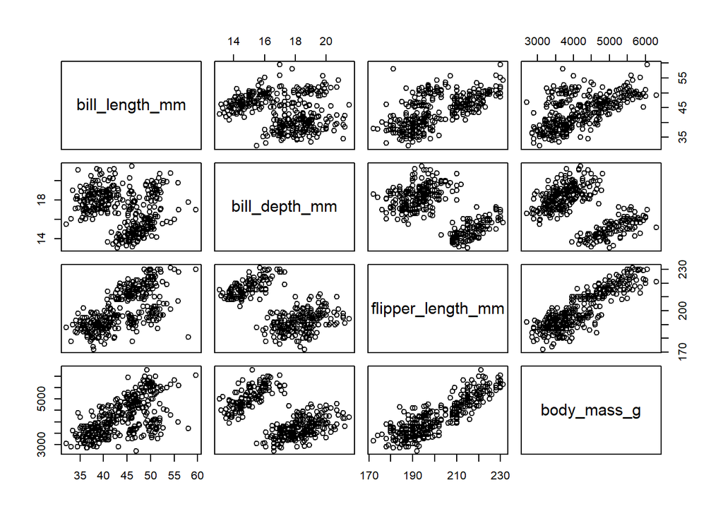

```r
#names(penguins)
pairs( select(penguins, bill_length_mm, bill_depth_mm, flipper_length_mm, body_mass_g) )
```

- Flipper length seems to be most clearly related to body mass so we can build a linear model based on that. In R we use the lm function to construct linear regression models (using the method of least squares).

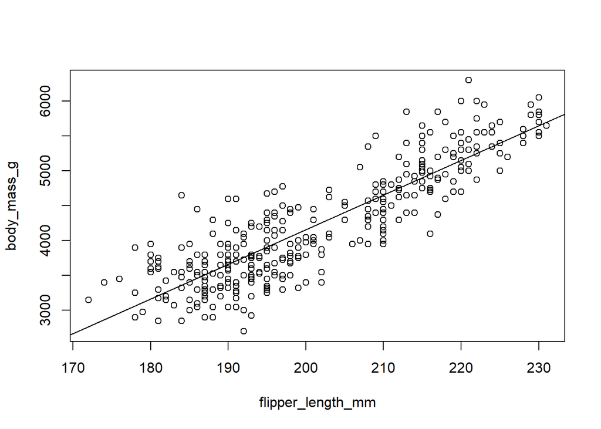

```r
# input X : flipper length
# output Y : body mass
model1 <- lm(body_mass_g ~ flipper_length_mm, data=penguins )
plot(body_mass_g ~ flipper_length_mm, data=penguins)
abline(model1) # y = a + bx
```

```r
summary(model1)
```

```
Call:
lm(formula = body_mass_g ~ flipper_length_mm, data = penguins)

Residuals:
     Min       1Q   Median       3Q      Max
-1058.80  -259.27   -26.88   247.33  1288.69

Coefficients:
                   Estimate Std. Error t value Pr(>|t|)
(Intercept)       -5780.831    305.815  -18.90   <2e-16 ***
flipper_length_mm    49.686      1.518   32.72   <2e-16 ***
---
Signif. codes:  0 '***' 0.001 '**' 0.01 '*' 0.05 '.' 0.1 ' ' 1

Residual standard error: 394.3 on 340 degrees of freedom
  (2 observations deleted due to missingness)
Multiple R-squared:  0.759, Adjusted R-squared:  0.7583
F-statistic:  1071 on 1 and 340 DF,  p-value: < 2.2e-16
```

- Resulting formula : `body_mass_g = -5780 + flipper_length_mm*49.686`
- We can look at the diagnostic plots for the fit using the following command.

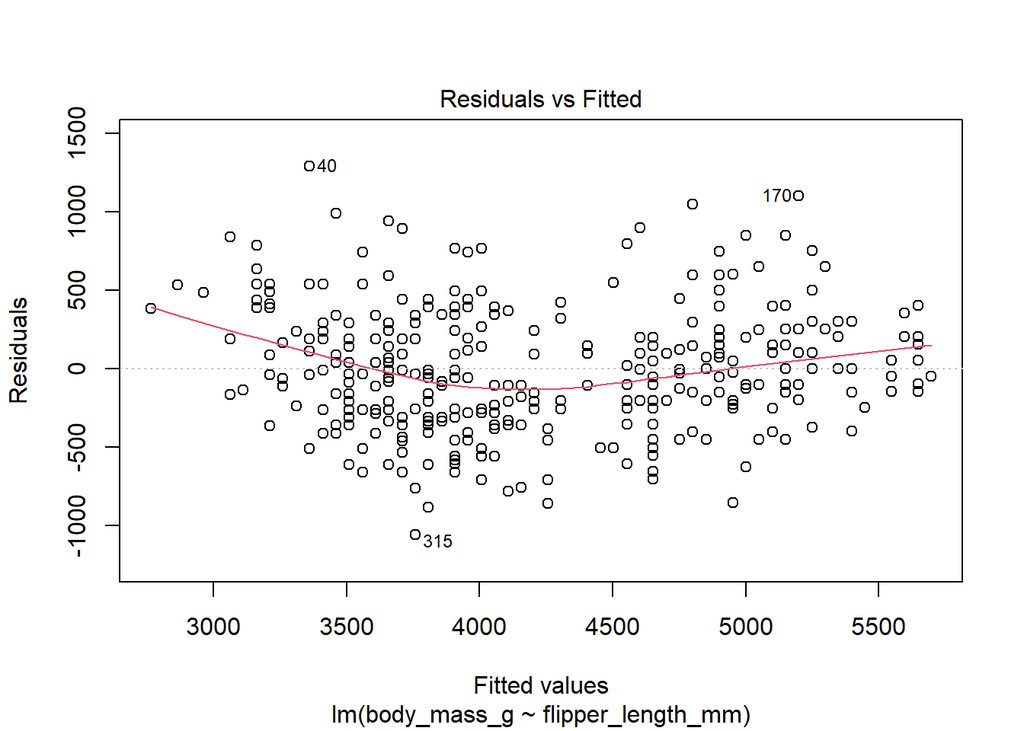

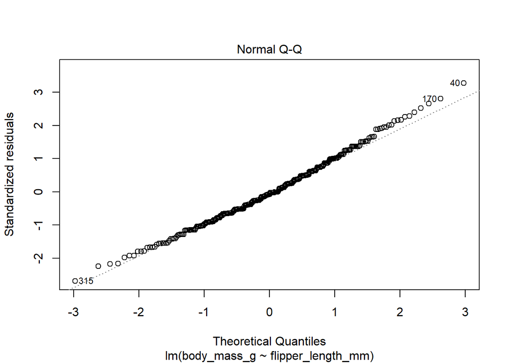

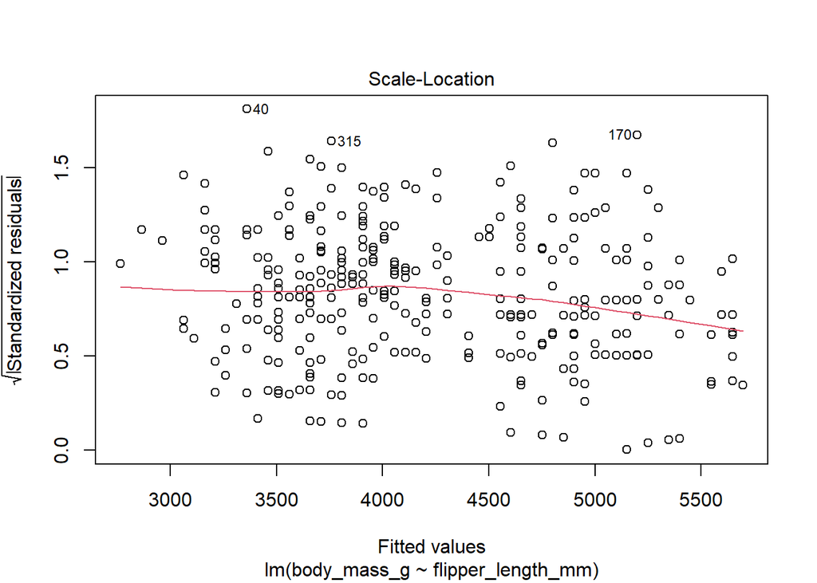

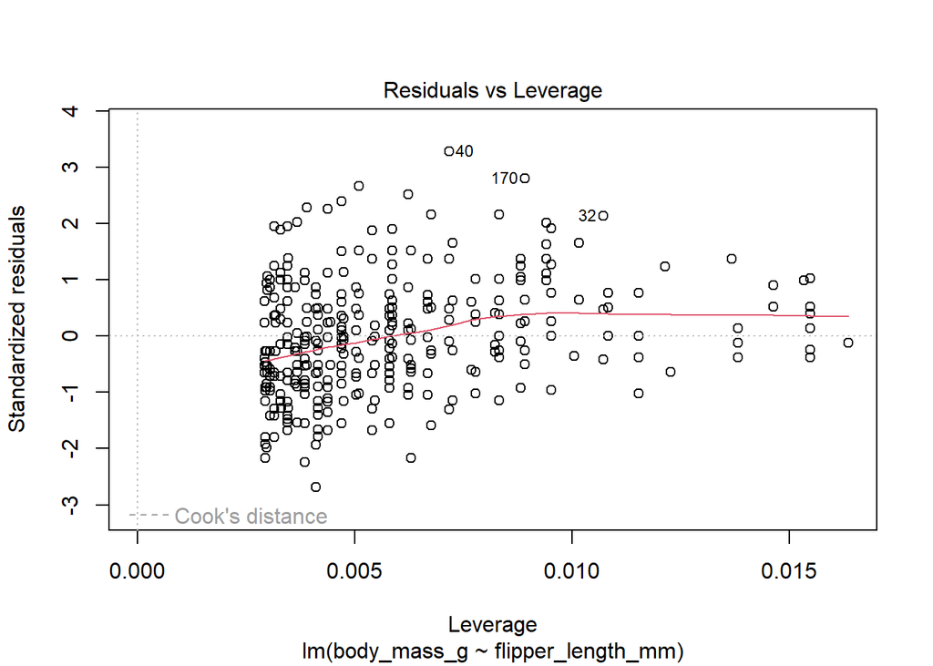

```r
plot(model1)
```

### **Examining residual and measuring performance**

- The line of best fit is chosen to minimise the sum of the squared residuals.
- If we want to manually work with the residuals we can access them with the following command:

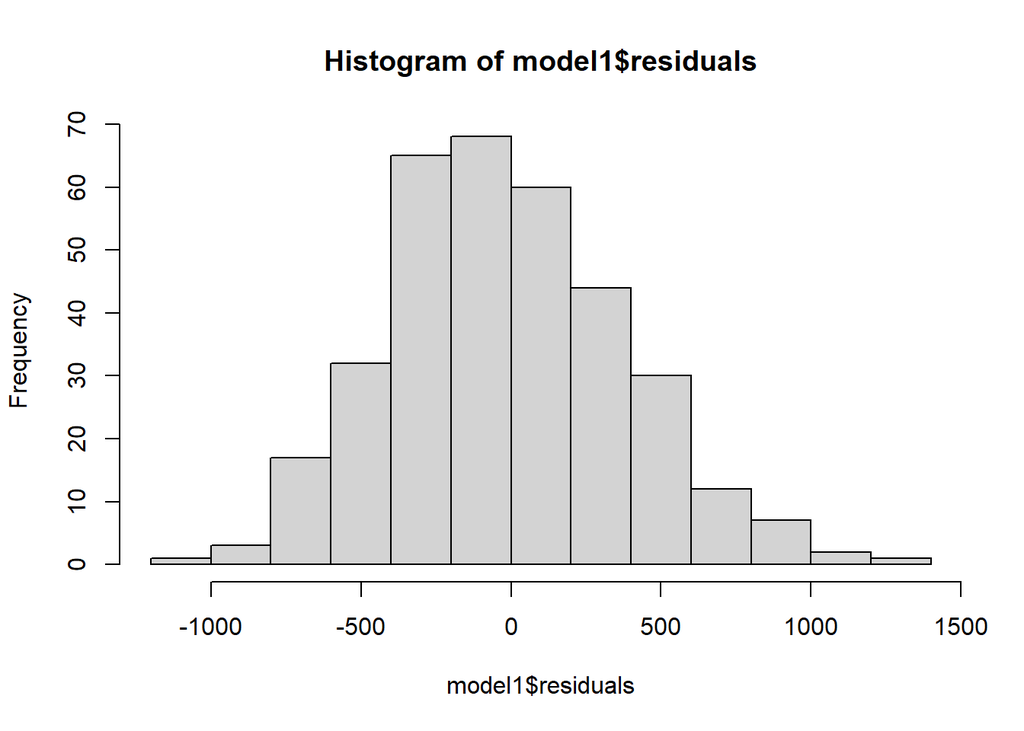

```r
# we can access the individual components of the fitted model
# using $
# e.g. access vector of residuals
# model1$residuals
# to plot the residuals
hist(model1$residuals)
```

**Recall**

RSS is a measure of the discrepancy between the observed values of the target variable $y$ and the values predicted by the model $ŷ$. Mathematically, RSS is calculated as the sum of the squared differences between the observed values of $y$ and the predicted values of $ŷ$:

$$\text{RSS} = \sum_{i=1}^{n} (y_i - \hat{y}_i)^2$$

- Here,
- $y_i$ represents the observed value of the target variable for the i-th data point, and
- $\hat{y}_i$ represents the predicted value of the target variable for the $i^{th}$ data point.

## RMSE (Root Mean Squared Error)

- RMSE is a measure of the average magnitude of the residuals (the differences between predicted and actual values) of the model.
- It is calculated by taking the square root of the average of squared differences between predicted and actual values:

$$\text{RMSE} = \sqrt{\frac{1}{n} \sum_{i=1}^{n} (y_i - \hat{y}_i)^2}$$

RMSE gives a measure of how well the model predicts the target variable. - A lower RMSE indicates a better fit of the model to the data.

## R-squared (Coefficient of Determination)

R-squared is a statistical measure that represents the proportion of the variance in the dependent variable $y$ that is predictable from the independent variables (features) in the model. - It ranges from $0$ to $1$, where $0$ indicates that the model explains none of the variability of the response data around its mean, and $1$ indicates that the model explains all the variability. - R-squared is calculated as:

$$R^2 = 1 - \frac{\text{RSS}}{\text{TSS}}$$

where TSS (Total Sum of Squares) is the sum of the squared differences between the observed $y$ values and the mean of $y$.

- can quantify the quality of different fits using a number of related measures:
- RSS residual sum of squares
- MSE mean squared error $MSE =\frac{RSS}{N}$
- RMSE root mean squared error $RMSE =\sqrt{MSE}$
- We can calculate these in R using:

```r
# measures of fit performance
# RSS sum of squared residuals
res <- model1$residuals
RSS <- sum(res^2)
RSS
```

```
[1] 52854796
```

```r
n <- nrow(penguins)
# MSE mean squared error
MSE <- RSS/n
MSE
```

```
[1] 153647.7
```

```r
# RMSE root mean squared error
RMSE <- sqrt(MSE)
RMSE
```

```
[1] 391.9792
```

- Note that the measure of fit shown in the summary is the R squared value. We can access this from the fit using code like:

```r
summary(model1)$r.squared
```

```
[1] 0.7589925
```

### Comparing Models

- To see how the performance of the model above compares with other possible models let’s build a model predicting body mass using bill length as the predictor variable:

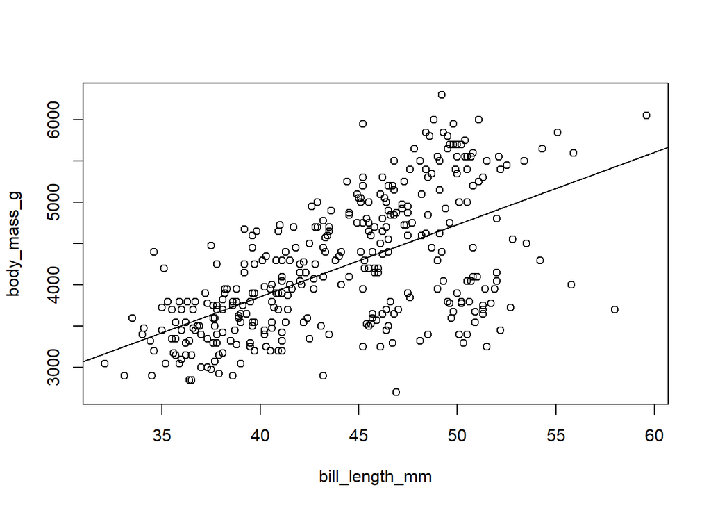

```r
# input X : bill length
# output Y : body mass
model2 <- lm(body_mass_g ~ bill_length_mm, data=penguins )
plot(body_mass_g ~ bill_length_mm, data=penguins)
abline(model2) # y = a + bx
```

```r
summary(model2)
```

```
Call:
lm(formula = body_mass_g ~ bill_length_mm, data = penguins)

Residuals:
     Min       1Q   Median       3Q      Max
-1762.08  -446.98    32.59   462.31  1636.86

Coefficients:
               Estimate Std. Error t value Pr(>|t|)
(Intercept)     362.307    283.345   1.279    0.202
bill_length_mm   87.415      6.402  13.654   <2e-16 ***
---
Signif. codes:  0 '***' 0.001 '**' 0.01 '*' 0.05 '.' 0.1 ' ' 1

Residual standard error: 645.4 on 340 degrees of freedom
  (2 observations deleted due to missingness)
Multiple R-squared:  0.3542,    Adjusted R-squared:  0.3523
F-statistic: 186.4 on 1 and 340 DF,  p-value: < 2.2e-16
```

- body_mass_g = 362.307 + bill_length_mm*87.415
- To compare multiple models we can make use of the texreg package `install.packages("texreg")` to install this.
- The screenreg function lets us display a comparison of regression fits on the screen.

```r
library(texreg)
```

```r
# we have to pass models to the function as a list
screenreg( list(model1,model2) )
```

```
============================================
                   Model 1       Model 2
--------------------------------------------
(Intercept)        -5780.83 ***   362.31
                    (305.81)     (283.35)
flipper_length_mm     49.69 ***
                      (1.52)
bill_length_mm                     87.42 ***
                                   (6.40)
--------------------------------------------
R^2                    0.76         0.35
Adj. R^2               0.76         0.35
Num. obs.            342          342
============================================
*** p < 0.001; ** p < 0.01; * p < 0.05
```

### Transforming variables

- In some cases we see that we can transform a relationship to a linear form by taking the logarithm of the data. Typical transformations are plotting $\log(y)$ against $x$ (when the underlying relationship is $y = a \times bx$) or plotting $\log(y)$ against $\log(x)$ when the underlying relationship is $y = a \times xb$).
- We can do this using code like the following:

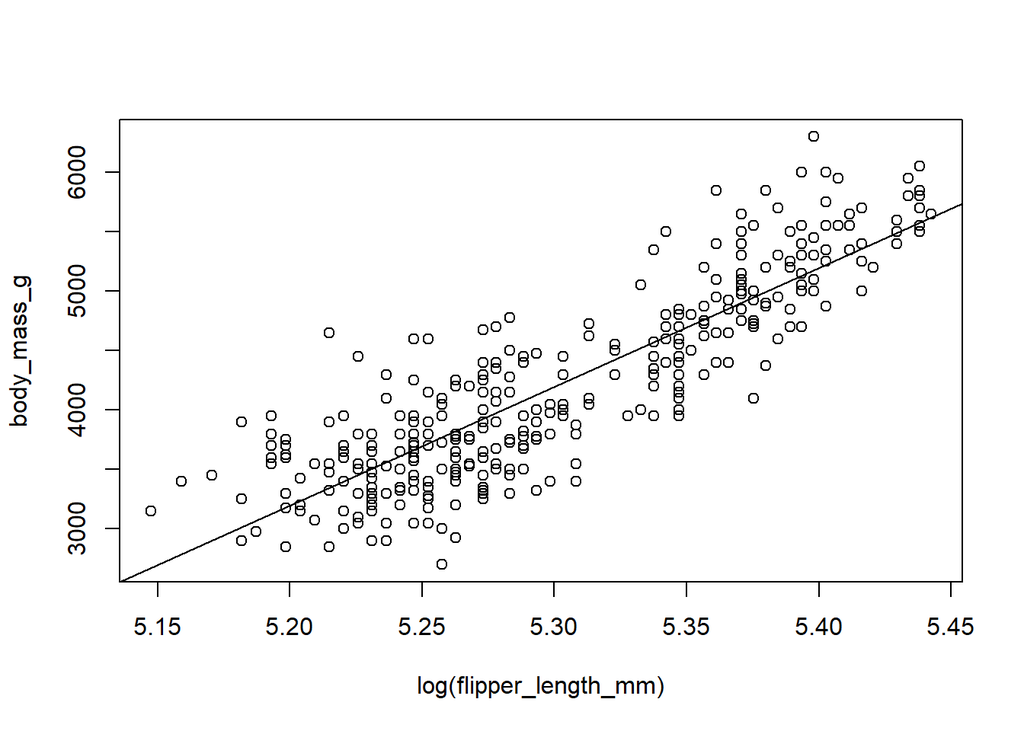

```r
model3 <- lm(body_mass_g ~ log(flipper_length_mm), data=penguins )
plot(body_mass_g ~ log(flipper_length_mm), data=penguins)
abline(model3)
```

```r
screenreg(list(model1,model2,model3))
```

```
================================================================
                        Model 1       Model 2      Model 3
----------------------------------------------------------------
(Intercept)             -5780.83 ***   362.31      -48861.03 ***
                         (305.81)     (283.35)      (1658.59)
flipper_length_mm          49.69 ***
                           (1.52)
bill_length_mm                          87.42 ***
                                        (6.40)
log(flipper_length_mm)                              10010.96 ***
                                                     (312.89)
----------------------------------------------------------------
R^2                         0.76         0.35           0.75
Adj. R^2                    0.76         0.35           0.75
Num. obs.                 342          342            342
================================================================
*** p < 0.001; ** p < 0.01; * p < 0.05
```

- In this case fitting body mass against log(flipper length) did not improve the fit (which might be expected as there is no visual evidence that the relationship between the two follows a non-linear power law relationship).
- Another way to work with log transformed values is to add columns to the dataset e.g.

```r
penguins <- penguins %>%
mutate( log_flipper_length_mm = log(flipper_length_mm),
log_body_mass_g = log(body_mass_g) )
```

### Multivariate Fitting Variables

- So far the fits we have looked at include only one predictor. However it is easy in R to make a linear model that includes several predictors:

```r
# sometimes taking the log of a variable can transform
# the relationship with the output to a linear relation
model4 <- lm(body_mass_g ~ flipper_length_mm + bill_length_mm + bill_depth_mm + species
, data=penguins )
summary(model4)
```

```
Call:
lm(formula = body_mass_g ~ flipper_length_mm + bill_length_mm +
    bill_depth_mm + species, data = penguins)

Residuals:
   Min     1Q Median     3Q    Max
-836.0 -200.7  -23.0  202.5 1045.9

Coefficients:
                   Estimate Std. Error t value Pr(>|t|)
(Intercept)       -4327.327    494.866  -8.744  < 2e-16 ***
flipper_length_mm    20.241      3.105   6.518 2.61e-10 ***
bill_length_mm       41.468      7.163   5.789 1.62e-08 ***
bill_depth_mm       140.328     18.976   7.395 1.14e-12 ***
speciesChinstrap   -513.247     82.140  -6.248 1.25e-09 ***
speciesGentoo       934.887    140.778   6.641 1.26e-10 ***
---
Signif. codes:  0 '***' 0.001 '**' 0.01 '*' 0.05 '.' 0.1 ' ' 1

Residual standard error: 315.9 on 336 degrees of freedom
  (2 observations deleted due to missingness)
Multiple R-squared:  0.8471,    Adjusted R-squared:  0.8449
F-statistic: 372.4 on 5 and 336 DF,  p-value: < 2.2e-16
```

- We see that adding in all variables including species makes a significant improvement to our model performance (R squared value has increased to 0.85). This might be expected because we know different species have different body shapes.
- In this case the final formula for predicting body mass from the set of inputs is:

```r
#body_mass_g= -4327.327 + 20.241* flipper_length_mm
#                        + 41.468*bill_length_mm
#                       +140.328*bill_depth_mm
#                       -513.247*speciesChinstrap
#                       + 934.887*speciesGentoo
```

- Note that because species is a category variable, R adds in dummy variables speciesChinstrap and speciesGentoo.
- speciesChinstrap is a variable that has value 1 for entries of species Chinstrap, and 0 otherwise.
- speciesGentoo is a variable that has value 1 for entries of species Gentoo, and 0 otherwise.
- Effectively the coefficients of these variables encode the average difference in mass between the baseline category of species Adelie, i.e.
  - the average Chinstrap penguin weighs 513g less than the average Adelie penguin
  - the average Gentoo penguin weighs 935g more than the average Adelie penguin

```r
# measures of fit performance
# RSS summ of squared residuals
res <- model2$residuals
RSS <- sum(res^2)
RSS
```

```
[1] 141638626
```

```r
n <- nrow(penguins)
# MSE mean squared error
MSE <- RSS/n
MSE
```

```
[1] 411740.2
```

```r
# RMSE root mean squared error
RMSE <- sqrt(MSE)
RMSE
```

```
[1] 641.6698
```

### Making Predictions

- Using the model to predict body weights for new data
- Visualizing predictions

```r
flipper_length_mm <- c(180, 210, 225)
new_data <- data.frame(flipper_length_mm = flipper_length_mm)
body_mass_predicted <- predict(model1, new_data)
body_mass_predicted
```

```
       1        2        3
3162.571 4653.138 5398.421
```

```r
predict(model1, new_data, interval="confidence", level=0.95)
```

```
       fit      lwr      upr
1 3162.571 3087.333 3237.808
2 4653.138 4603.189 4703.086
3 5398.421 5315.157 5481.685
```

**Extra notes: Converting Numeric Values to Category values**

- In some cases it is useful to segment our dataset into groups based on a numerical value.
- We can do this with the `cut` function.
- This takes a series of breaks to bin the data, and optionally labels that can be used to label the resulting groups.
- As an example lets view the distribution of penguin weights and split them into categories of small medium and large penguins.

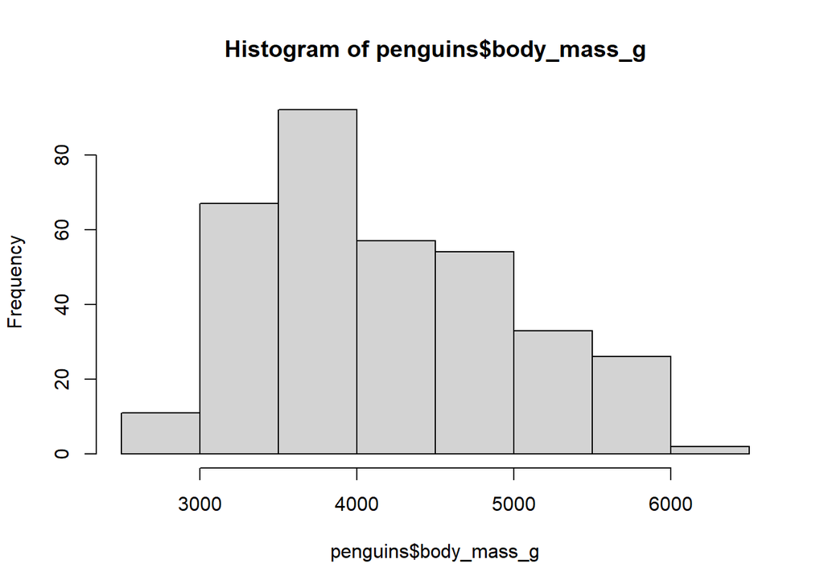

```r
hist(penguins$body_mass_g)
```

- convert weight to small (<3000g) medium (3000 to 5000g) and large (>5000g)

```r
# the cut function can convert a numeric to factor variable
penguins <- penguins %>% mutate( size = cut(body_mass_g,
breaks=c(0,3000,5000,10000),
labels=c("small","medium","large")))
summary(penguins$size)
```

```
 small medium  large   NA's
    11    270     61      2
```

- If we want more groups it can be useful to use the `seq` function to generate the breaks.
- We can also use `cut_number`, `cut_interval`, `cut_width` from the tidyverse that can help choose automated groupings (google tidyverse cut to see how these can be used).

```r
# the cut function can uses seq to generate a series of cut points
penguins <- penguins %>% mutate( size = cut(body_mass_g,
breaks= seq(2000,8000,500) ))
table(penguins$size)
```

```
(2e+03,2.5e+03] (2.5e+03,3e+03] (3e+03,3.5e+03] (3.5e+03,4e+03] (4e+03,4.5e+03]
              0              11              67              92              57
(4.5e+03,5e+03] (5e+03,5.5e+03] (5.5e+03,6e+03] (6e+03,6.5e+03] (6.5e+03,7e+03]
             54              33              26               2               0
(7e+03,7.5e+03] (7.5e+03,8e+03]
              0               0
```

## 2. Multivariate Linear Regression Models Using Real Estate Dataset

### Dataset Description

- To begin with, download and open the datafile: `real_estate.csv`. This dataset stores data on house prices (normalized to per unit area, e.g., price per square meter).
- The columns in this dataset are:
  - **sale_date**: Year and date (decimal) corresponding to the sale date.
  - **house_age**: Age of the house in years.
  - **dist_to_transport**: Distance to the nearest train station.
  - **num_stores**: Number of stores close by (within a certain radius) of the property.
  - **longitude**: Longitudinal coordinate of the property.
  - **latitude**: Latitude coordinate of the property.
  - **price_per_sqm**: Price of the property per square meter.

**Exercise 1**

- Load in the data file.
- Check that the data types are set up appropriately.
- Check the amount of data in the dataset, and whether there is any missing data.
- Think: What relationships might you expect to find in this dataset?
- Explore the relationships between the variables and the price.
- Identify which factors seem to be most important in determining house price.
- Determine if there are any factors that do not seem important.
- Investigate other relationships between the input variables.
- Once you have explored the data, try to make plots that illustrate your key findings.

### Objectives

We want to use this dataset to:

1. Understand the factors that make some houses more expensive than others.
2. Build a statistical model to predict an appropriate house price for a property.